# Zaawansowana Analiza Szeregów Czasowych - projekt

Norbert Burmistrzak & Michał Staniaszek

30.06.2022

## **WSTĘP**

- BNB
- Monero
- Stellar
- Neo

Oszacowano funkcje warunkowej wariancji za pomocą modeli klasy GARCH oraz 1% wartości narażonej na ryzyko (Value at Risk - VaR) w okresie out of sample. Dane wykorzystane w projekcie pochodzą ze strony https://www.coingecko.com/.

#### WCZYTANIE BIBLIOTEK

```r
library('readr')
library('xts')
library('dygraphs')
library('car')
library('FinTS')
library('fBasics')
library('tseries')
library('rugarch')
```

## **PRZYGOTOWANIE DANYCH**

```r
bnb <- read_csv("BNB.csv")
neo <- read_csv("Neo.csv")
monero <- read_csv("Monero.csv")
stellar <- read_csv("Stellar.csv")
```

##### UCIĘCIE OBSERWACJI

Wybrano maksymalną liczbę obserwacji dla kryptowaluty będącej najkrócej na rynku, tak by każdy szereg miał tą samą długość.

```r
bnb = tail(bnb, n = 1747)
neo = tail(neo, n = 1747)
monero = tail(monero, n = 1747)
stellar = tail(stellar, n = 1747)
```

##### ZMIANA FORMATU DATY

```r
bnb$Date <- as.Date(format(as.POSIXlt(bnb$snapped_at), format = "%Y-%m-%d"))
neo$Date <- as.Date(format(as.POSIXlt(neo$snapped_at), format = "%Y-%m-%d"))
monero$Date <- as.Date(format(as.POSIXlt(monero$snapped_at), format = "%Y-%m-%d"))
stellar$Date <- as.Date(format(as.POSIXlt(stellar$snapped_at), format = "%Y-%m-%d"))
```

##### FORMATOWANIE KOLUMN

```r
bnb = bnb[c(5,3,2)]
neo = neo[c(5,3,2)]
monero = monero[c(5,3,2)]
stellar = stellar[c(5,3,2)]

colnames(bnb) = c("Date","B_market_cup","B_price")
colnames(neo) = c("Date","N_market_cup","N_price")
colnames(monero) = c("Date","M_market_cup","M_price")
colnames(stellar) = c("Date","S_market_cup","S_price")
```

##### ŁĄCZENIE TABEL

```r
data = merge(bnb, monero, by.x = "Date", by.y = "Date")
data = merge(data, neo, by.x = "Date", by.y = "Date")
data = merge(data, stellar, by.x = "Date", by.y = "Date")
```

Transofrmacja danych i połączenie ich w zbiorową tabele pozwala przejść do budowy portfela składającego się ze wszystkich 4 wybranych wcześniej kryptowalut

## **BUDOWA PORTFELA**

```r
data$total_market_cup = data$B_market_cup + data$M_market_cup + data$N_market_cup + data$S_market_cup

data$B_p = data$B_market_cup/data$total_market_cup
data$N_p = data$N_market_cup/data$total_market_cup
data$M_p = data$M_market_cup/data$total_market_cup
data$S_p = data$S_market_cup/data$total_market_cup
```

##### FORMATOWANIE KOLUMN

```r
data = data[-c(2, 4, 6, 8, 10)]
```

##### STOPY ZWROTU

```r
data$B_r = diff.xts(log(data$B_price))
data$N_r = diff.xts(log(data$N_price))
data$M_r = diff.xts(log(data$M_price))
data$S_r = diff.xts(log(data$S_price))
```

##### STOPA ZWROTU Z PORTFELA

```r
data$total_r = (data$B_p*data$B_r
                +data$S_p*data$S_r
                +data$M_p*data$M_r
                +data$N_p*data$N_r)
```

##### UDZIAŁ W CZASIE

```r
share_xts = xts(data[, c("B_p", "N_p", "S_p", "M_p")], order.by = data$Date)
tot_ret_xts = xts(data[, c("total_r")], order.by = as.Date(data$Date))
close_xts = xts(data[, c("B_price", "N_price", "S_price", "M_price")], order.by = data$Date)
```

##### CENY ZAMKNIECIA

```r
dygraph(close_xts, main = 'Ceny zamknięcia') %>%
  dyRangeSelector(height = 50)
```

[interactive chart not shown]

##### PROFIL PORTFELOWY

```r
dygraph(share_xts, main = "Profil portfelowy") %>%
  dyRangeSelector(height = 40)
```

[interactive chart not shown]

Przez okres pierwszych 3 lat nasz portfel jest zdywersyfikowany, natomiast w okolicach lutego 2021 BNB zaczyna stanowić średnio 60-80% wartości całego portfela, wiąże się to przede wszystkim z kilkutysięczno procentowym skokiem wartości ceny dla kryptowaluty. Bardzo zbliżone zachowanie wartości na rynku jest widoczne dla walut Monero oraz Neo. BNB cechowało się trendem wzrostowym przez większość analizowane okresu z minimalnym załamaniem w grudniu 2020. Z powodu znacznego wzrostu BNB udział zarówno Monero jak i NEO spadł poniżej 10%, a dla Stellar jest to jedynie 1%.

##### STOPY ZWROTOW

```r
dygraph(tot_ret_xts, main="Stopy zwrotów") %>%
  dyRangeSelector(height = 50)
```

[interactive chart not shown]

##### BADANIE AUTOKORELACJI RESZT

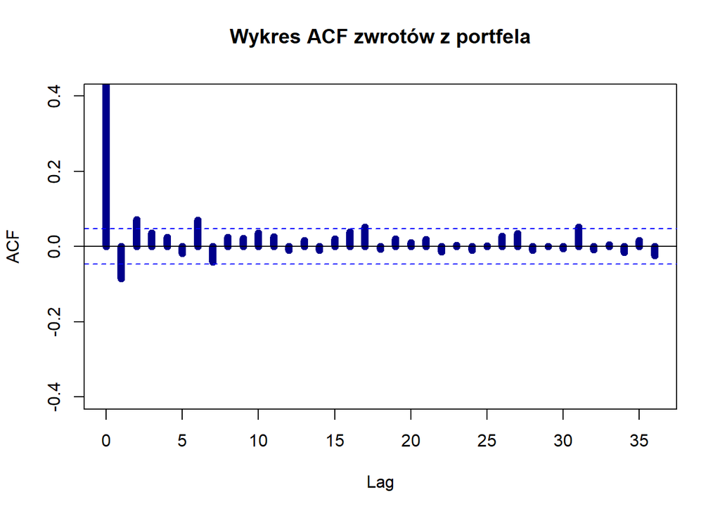

```r
# Wykres ACF dla zwrotow z portfela
acf(data$total_r, lag.max = 36, na.action = na.pass,
    ylim = c(-0.4, 0.4),
    col = "darkblue", lwd = 7,
    main = "Wykres ACF zwrotów z portfela")
```

Dla wykresu ACF można zaobserwować występowanie trendu. Stopniowe wygaszanie jest przerywane cykliczną istotnościa jednego z opóźnień. Warto potwierdzić obserwacje wizualne formalnym testem Durbina - Watsona

```r
durbinWatsonTest(lm(data$total_r ~ 1),
                 max.lag = 5)
```

```
##  lag Autocorrelation D-W Statistic p-value
##    1     -0.08564984      2.170770   0.000
##    2      0.07172137      1.855676   0.006
##    3      0.03578811      1.925225   0.106
##    4      0.02429640      1.947771   0.378
##    5     -0.01835972      2.032627   0.474
##  Alternative hypothesis: rho[lag] != 0
```

Test Durbina - Watsona wskazuje na autokorelacje dla 1 i 2 opóźnienia.

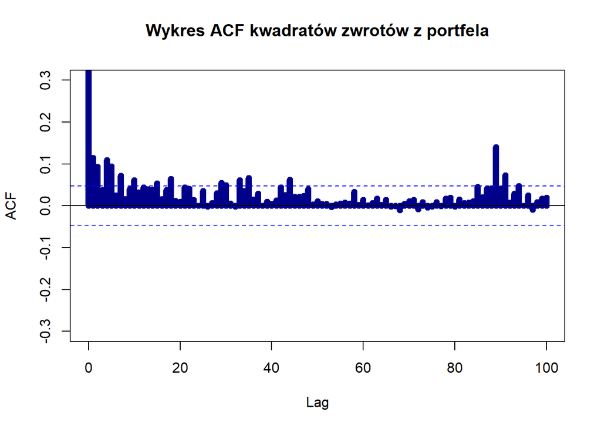

```r
# Wykresy ACF^2 dla zwrotow z portfela (efekty ARCH)
acf(data$total_r^2, lag.max = 100, na.action = na.pass,
    ylim = c(-0.3, 0.3),
    col = "darkblue", lwd = 7,
    main = "Wykres ACF kwadratów zwrotów z portfela")
```

```r
#test ARCH
ArchTest(data$total_r, lags = 5)
```

```
##
##  ARCH LM-test; Null hypothesis: no ARCH effects
##
## data:  data$total_r
## Chi-squared = 59.665, df = 5, p-value = 1.426e-11
```

P-value w LM testująca występowanie efektów ARCH jest bliskie 0, co oznacza, że należy odrzucić H0 mówiącą o braku występowania efektów ARCH.

```r
#Test na autokorelacje kwadratów reszt  -> autokorelacja dla 1% poziomu istotności
durbinWatsonTest(lm(data$total_r^2 ~ 1),
                 max.lag = 5)
```

```
##  lag Autocorrelation D-W Statistic p-value
##    1      0.11491724      1.770133   0.006
##    2      0.09315432      1.813607   0.024
##    3      0.03805573      1.923359   0.130
##    4      0.10970373      1.780024   0.020
##    5      0.09415609      1.811071   0.030
##  Alternative hypothesis: rho[lag] != 0
```

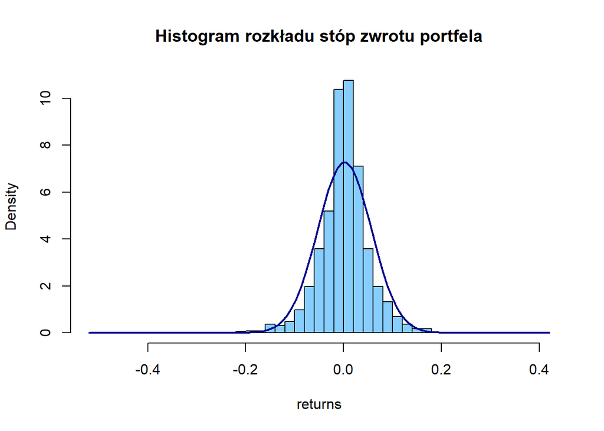

```r
#Porównanie rozkładu z rozkładem normalnym
hist(data$total_r, prob = T, breaks = 50, main = "Histogram rozkładu stóp zwrotu portfela", xlab="returns", col="skyblue1")
curve(dnorm(x, mean = mean(data$total_r, na.rm = T),
            sd  = sd(data$total_r, na.rm = T)),
      col = "darkblue", lwd = 2, add = TRUE,
)
```

Histogram rozkładu stóp zwrotu z portfela wskazuje na rozkład leptokurtyczny. Osiągnięte maksimum jest dużo wyższe niż dla rozkładu normalnego, dodatkowo można zaobserwować grubsze ogony dla rozkładu empirycznego.

##### STATYSTYKI OPISOWE

```r
empstats <- basicStats(data$total_r)
knitr::kable(as.matrix(empstats), digits = 2)
```

|  | X..data.total_r |
| --- | --- |
| nobs | 1744.00 |
| NAs | 1.00 |
| Minimum | -0.52 |
| Maximum | 0.41 |
| 1. Quartile | -0.02 |
| 3. Quartile | 0.03 |
| Mean | 0.00 |
| Median | 0.00 |
| Sum | 3.21 |
| SE Mean | 0.00 |
| LCL Mean | 0.00 |
| UCL Mean | 0.00 |
| Variance | 0.00 |
| Stdev | 0.05 |
| Skewness | -0.54 |
| Kurtosis | 10.08 |

Statystyki zdają się potwierdzać analizę wizualną. Występuję skośność oraz dodatnia kurtoza, która również jest charakterystyczna dla rozkładu leptokurtycznego.

##### TEST NA NORMALNOSC

```r
jbtest <- jarque.bera.test(na.omit(data$total_r))
jbtest
```

```
##
##  Jarque Bera Test
##
## data:  na.omit(data$total_r)
## X-squared = 7479.7, df = 2, p-value < 2.2e-16
```

Formalnym potwierdzeniem braku rozkładu normalnego jest przeprowadzenie testu Jarque-Bera. P-value w teście bliskie 0, a więc odrzucamy H0 o rozkładzie normalnym.

## **GARCH**

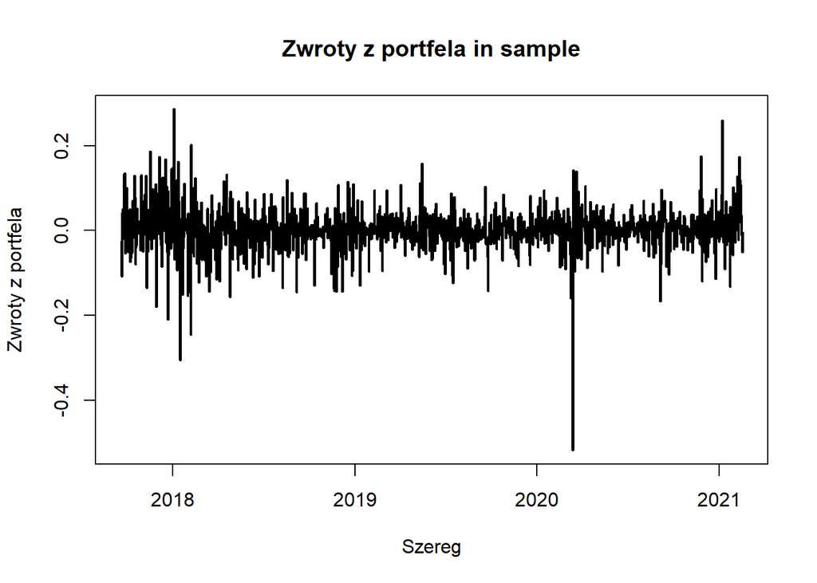

```r
# in sample (1246 obserwacji)
ins = data[which(data$Date < "2021-02-18"),]


# out of sample (498 obserwacje)
outs = data[-which(data$Date < "2021-02-18"),]


# wykresy zwrotów in sample i out of sample
plot(ins$Date, ins$total_r, type = "l", col = "black", lwd = 2, main = "Zwroty z portfela in sample",
     xlab = "Szereg", ylab = "Zwroty z portfela")
```

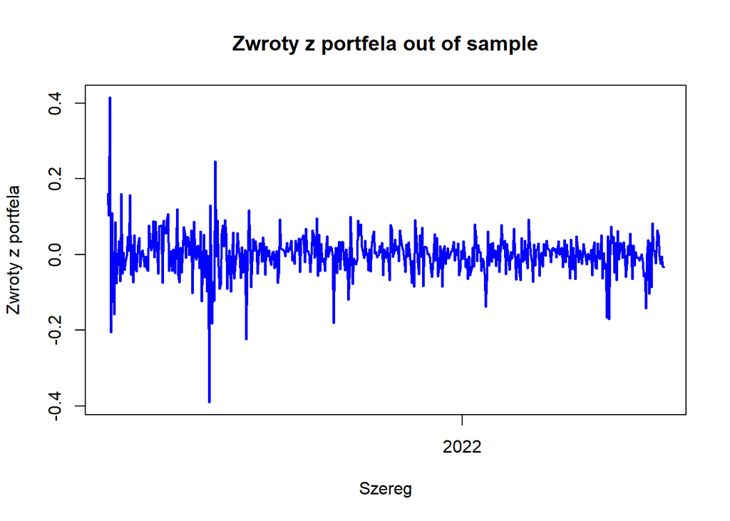

```r
plot(outs$Date, outs$total_r, type = "l", col = "blue", lwd = 2, main = "Zwroty z portfela out of sample",
     xlab = "Szereg", ylab = "Zwroty z portfela")
```

Okres out of sample stanowi około 30% próby. Podobna skala jest powszechnie wykorzystywana w tego typu analizach. Na wykresach widzimy charakterystyczne dla danych finansowych grupowanie wariancji. Zdecydowanie najwyższa wariancja występuje w okolicach przełomu 2017 i 2018 roku oraz 2020 i 2021. Stopy zwrotów z portfela odnotowały drastyczny, lecz krótkotrwały spadek, gdy pandemia COVID dotarła do świata zachodniego.

##### DOPASOWANIE NAJLEPSZEGO MODELU

```r
# GARCH(1,1) #


spec <- ugarchspec(variance.model = list(model = "sGARCH",
                                         garchOrder = c(1, 1)),
                   mean.model = list(armaOrder = c(0, 0),
                                     include.mean = T),
                   distribution.model = "norm")

ins.garch11 <- ugarchfit(spec = spec,
                         data = na.omit(ins$total_r))


# MA(1)-GARCH(1,1) #

spec <- ugarchspec(variance.model = list(model = "sGARCH",
                                         garchOrder = c(1, 1)),
                   mean.model = list(armaOrder = c(0, 1),
                                     include.mean = T),
                   distribution.model = "norm")

ins.garch11ma1 <- ugarchfit(spec = spec,
                            data = na.omit(ins$total_r))

# AR(1)-GARCH(1,1) #

spec <- ugarchspec(variance.model = list(model = "sGARCH",
                                         garchOrder = c(1, 1)),
                   mean.model = list(armaOrder = c(1, 0),
                                     include.mean = T),
                   distribution.model = "norm")

ins.garch11ar1 <- ugarchfit(spec = spec,
                            data = na.omit(ins$total_r))

# ARMA(1,1)-GARCH(1,1) #

spec <- ugarchspec(variance.model = list(model = "sGARCH",
                                         garchOrder = c(1, 1)),
                   mean.model = list(armaOrder = c(1, 1),
                                     include.mean = T),
                   distribution.model = "norm")

ins.garch11arma11 <- ugarchfit(spec = spec,
                               data = na.omit(ins$total_r))

# GARCH(1,1) mu = 0 #

spec <- ugarchspec(variance.model = list(model = "sGARCH",
                                         garchOrder = c(1, 1)),
                   mean.model = list(armaOrder = c(0,0),
                                     include.mean = F),
                   distribution.model = "norm")

ins.garch11mu0 <- ugarchfit(spec = spec,
                                  data = na.omit(ins$total_r))

# ARMA(1,1)-GARCH(1,1) mu = 0 #

spec <- ugarchspec(variance.model = list(model = "sGARCH",
                                         garchOrder = c(1, 1)),
                   mean.model = list(armaOrder = c(1, 1),
                                     include.mean = F),
                   distribution.model = "norm")

ins.garch11arma11mu0 <- ugarchfit(spec = spec,
                                  data = na.omit(ins$total_r))

# MA(1)-GARCH(1,1) mu = 0  #

spec <- ugarchspec(variance.model = list(model = "sGARCH",
                                         garchOrder = c(1, 1)),
                   mean.model = list(armaOrder = c(0, 1),
                                     include.mean = F),
                   distribution.model = "norm")

ins.garch11ma1mu0 <- ugarchfit(spec = spec,
                               data = na.omit(ins$total_r))
# AR(1)-GARCH(1,1) mu = 0  #

spec <- ugarchspec(variance.model = list(model = "sGARCH",
                                         garchOrder = c(1, 1)),
                   mean.model = list(armaOrder = c(1, 0),
                                     include.mean = F),
                   distribution.model = "norm")

ins.garch11ar1mu0 <- ugarchfit(spec = spec,
                               data = na.omit(ins$total_r))
```

Zgodnie z powszechną praktyką przeważnie model GARCH(1,1) sprawdza się najlepiej. W związku z tym poddano analizie jego zróżnicowane kombinacje z modelami ARMA. Wzięto pod uwagę GARCH(1,1), AR(1)-GARCH(1,1), MA(1)-GARCH(1,1), ARMA(1,1)-GARCH(1,1) oraz analogiczne kombinacje modeli z uwzględnieniem parametru mi.

##### PORÓWNANIE WSZYSTKICH ZBUDOWANYCH MODELI

```r
infocriteria(ins.garch11)
```

```
##
## Akaike       -3.171735
## Bayes        -3.155263
## Shibata      -3.171756
## Hannan-Quinn -3.165541
```

```r
infocriteria(ins.garch11ma1)
```

```
##
## Akaike       -3.171993
## Bayes        -3.151403
## Shibata      -3.172025
## Hannan-Quinn -3.164251
```

```r
infocriteria(ins.garch11ar1)
```

```
##
## Akaike       -3.172229
## Bayes        -3.151639
## Shibata      -3.172261
## Hannan-Quinn -3.164487
```

```r
infocriteria(ins.garch11arma11)
```

```
##
## Akaike       -3.171586
## Bayes        -3.146878
## Shibata      -3.171633
## Hannan-Quinn -3.162296
```

```r
infocriteria(ins.garch11mu0)
```

```
##
## Akaike       -3.172078
## Bayes        -3.159724
## Shibata      -3.172089
## Hannan-Quinn -3.167432
```

```r
infocriteria(ins.garch11ma1mu0)
```

```
##
## Akaike       -3.172221
## Bayes        -3.155749
## Shibata      -3.172241
## Hannan-Quinn -3.166027
```

```r
infocriteria(ins.garch11ar1mu0)
```

```
##
## Akaike       -3.172454
## Bayes        -3.155982
## Shibata      -3.172474
## Hannan-Quinn -3.166260
```

```r
infocriteria(ins.garch11arma11mu0)
```

```
##
## Akaike       -3.171879
## Bayes        -3.151289
## Shibata      -3.171911
## Hannan-Quinn -3.164137
```

Następnie kierując się kryteriami informacyjnymi wybrano najlepszy model. Wnioski nie są jednoznaczne. Kryterium Bayesowskie oraz Hannan-Quinn osiąga najniższe wartości dla modelu GARCH(1,1), a Akaike i Shibata dla modelu AR(1)-GARCH(1,1). Jednakże po przeanalizowaniu wydruków okazuje się, że parametr przy zmiennej autoregresyjnej jest statystycznie nieistotny. Biorąc pod uwagę, że szacowanie zmiennych nieistotnych obniża efektywność modelu ostatecznie wybrano GARCH(1,1).

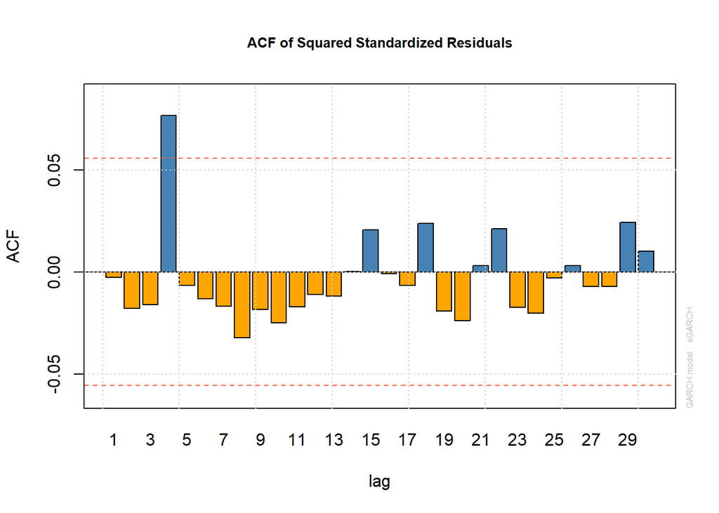

```r
plot(ins.garch11mu0, which = 11)
```

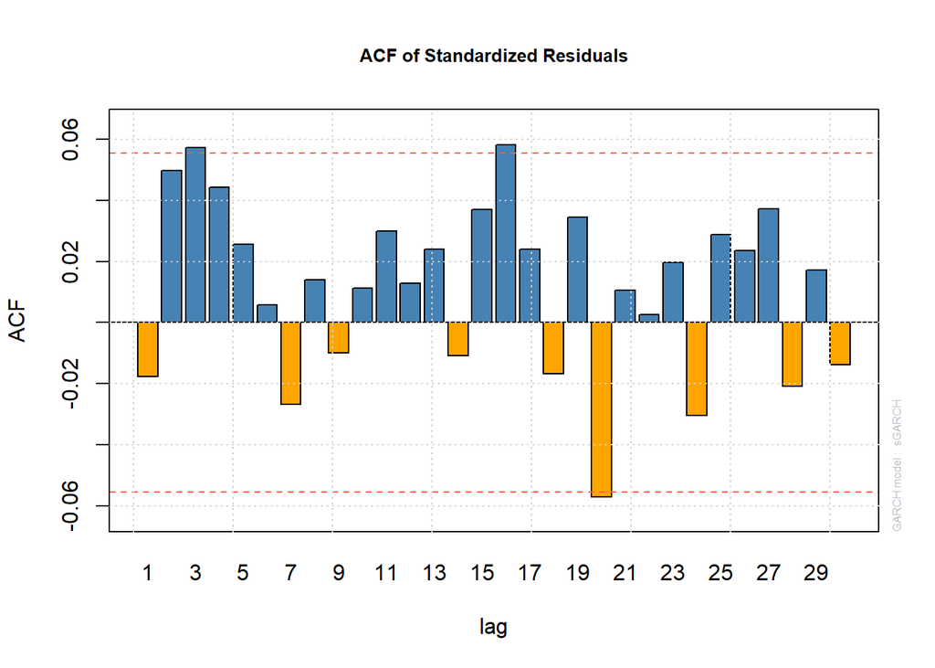

```r
plot(ins.garch11mu0, which = 10)
```

Powyższe wykresy sugerują, że autokorelacja reszt mogła nie zostać całkowicie zaabsorbowana przez model. Widzimy 3 istotne opóźnienia na wykresie ACF dla wystandaryzowanych reszt. Autokorelacji nie udało się wyeliminować nawet ustawiając bardzo wysokie paratemtry modelu i rozszerzając model o ARMA. Problem nie musi jednak oznaczać, że wyniki modelu są niewłaściwe. Po pierwsze próba jest dosyć duża, biorąc pod uwagę prostotę modelu (tylko dwie zmienne), a więc tego typu testy będą wykrywać nawet niewielkie nieprawidłowości. Po drugie dane finansowe są z reguły narażone na występowanie autokorelacji, więc jest ona w pewnym stopniu dopuszczalna. Znacznie większą przeszkodą byłaby obecność autokorelacji kwadratów reszt.

```r
ins.garch11mu0
```

```
##
## *---------------------------------*
## *          GARCH Model Fit        *
## *---------------------------------*
##
## Conditional Variance Dynamics
## -----------------------------------
## GARCH Model  : sGARCH(1,1)
## Mean Model   : ARFIMA(0,0,0)
## Distribution : norm
##
## Optimal Parameters
## ------------------------------------
##         Estimate  Std. Error  t value Pr(>|t|)
## omega   0.000075    0.000024   3.1910 0.001418
## alpha1  0.100359    0.018315   5.4797 0.000000
## beta1   0.881176    0.020660  42.6513 0.000000
##
## Robust Standard Errors:
##         Estimate  Std. Error  t value Pr(>|t|)
## omega   0.000075    0.000038   1.9860 0.047036
## alpha1  0.100359    0.040974   2.4493 0.014313
## beta1   0.881176    0.038421  22.9346 0.000000
##
## LogLikelihood : 1977.618
##
## Information Criteria
## ------------------------------------
##
## Akaike       -3.1721
## Bayes        -3.1597
## Shibata      -3.1721
## Hannan-Quinn -3.1674
##
## Weighted Ljung-Box Test on Standardized Residuals
## ------------------------------------
##                         statistic p-value
## Lag[1]                     0.3889 0.53285
## Lag[2*(p+q)+(p+q)-1][2]    1.9401 0.27291
## Lag[4*(p+q)+(p+q)-1][5]    6.4765 0.06934
```

[output cut: 34 more lines]

```
## Negative Sign Bias  0.7283 0.46656
## Positive Sign Bias  0.7797 0.43572
## Joint Effect        5.1649 0.16011
##
##
## Adjusted Pearson Goodness-of-Fit Test:
## ------------------------------------
##   group statistic p-value(g-1)
## 1    20     105.6    5.187e-14
## 2    30     117.6    1.261e-12
## 3    40     133.3    3.037e-12
## 4    50     150.1    3.484e-12
##
##
## Elapsed time : 0.07882905
```

Wszystkie zmienne w modelu są istotne. Parametry nie podlegają ilościowej interpretacji, przydadzą się przy prognozowaniu i wizualizacji graficznej. Formalne testy pokazują brak autokorelacji, autokorelacji kwadratów reszt i efektów ARCH w resztach. Oznacza to, że zostały one odpowiendio zaadresowane przez model.

##### HISTOGRAM RESZT MODELU GARCH(1,1) mi0

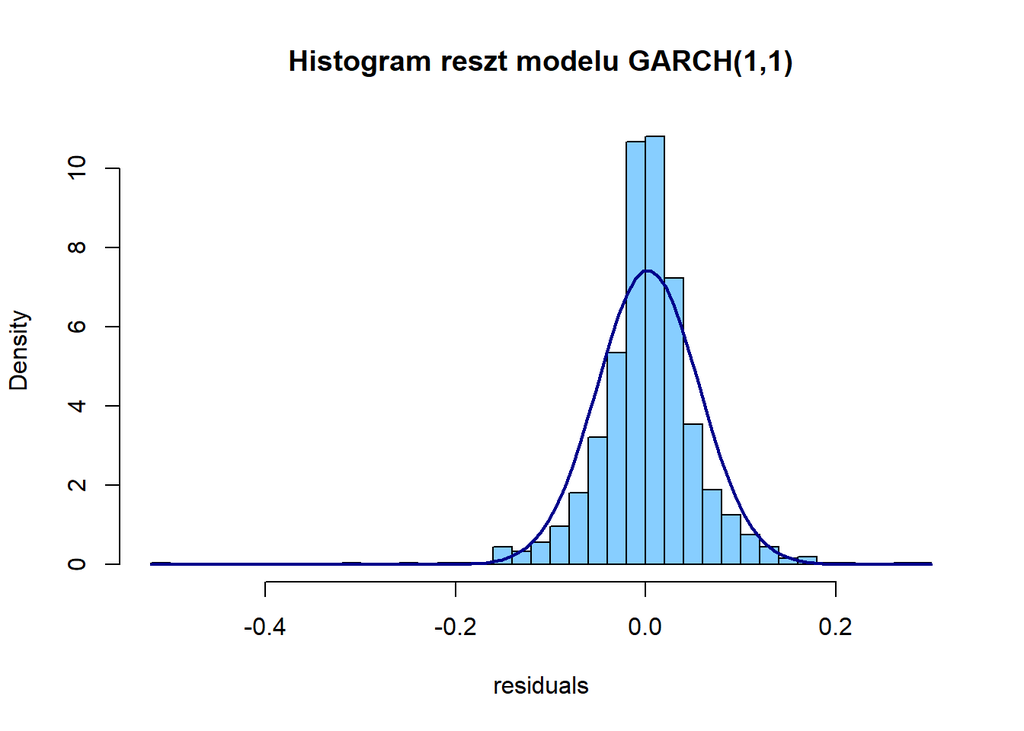

```r
hist(ins.garch11mu0@fit$residuals, prob = T, breaks = 50,
     main = "Histogram reszt modelu GARCH(1,1)", xlab="residuals", col="skyblue1")
curve(dnorm(x, mean = mean(ins.garch11mu0@fit$residuals, na.rm = T),
            sd  = sd(ins.garch11mu0@fit$residuals, na.rm = T)),
      col = "darkblue", lwd = 2, add = TRUE,
)
```

Graficzna analiza rozkładu reszt wskazuje na to, że odbiega on od normalnego. Obserwacje są silniej skupione wokół średniej i występuje wyższe prawdopowdobieństwo zaobserwowania wartości skrajnych.

##### STATYSTYKI RESZT MODELU

```r
empstats <- basicStats(ins.garch11mu0@fit$residuals)
knitr::kable(as.matrix(empstats), digits = 2)
```

|  | X..ins.garch11mu0.fit.residuals |
| --- | --- |
| nobs | 1245.00 |
| NAs | 0.00 |
| Minimum | -0.52 |
| Maximum | 0.29 |
| 1. Quartile | -0.02 |
| 3. Quartile | 0.03 |
| Mean | 0.00 |
| Median | 0.00 |
| Sum | 3.06 |
| SE Mean | 0.00 |
| LCL Mean | 0.00 |
| UCL Mean | 0.01 |
| Variance | 0.00 |
| Stdev | 0.05 |
| Skewness | -0.76 |
| Kurtosis | 9.89 |

##### RESZTY - BADANIE ROZKLADU

```r
jbtest_residuals <- jarque.bera.test(ins.garch11mu0@fit$residuals)
jbtest_residuals
```

```
##
##  Jarque Bera Test
##
## data:  ins.garch11mu0@fit$residuals
## X-squared = 5212.9, df = 2, p-value < 2.2e-16
```

Na każdym sensownym poziomie istotności należy odrzucić H0 o rozkładzie normalnym reszt.

##### WYKRES RESZT

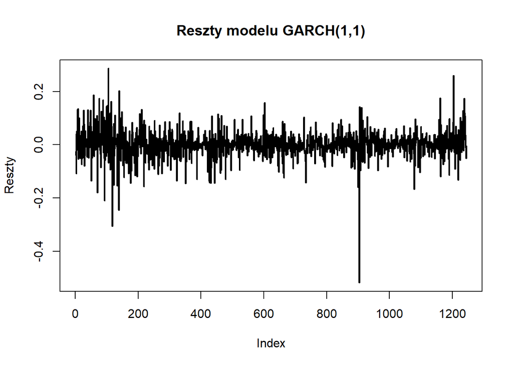

```r
plot(ins.garch11mu0@fit$residuals, type ="l", lwd = 2, main = "Reszty modelu GARCH(1,1)", ylab = "Reszty")
```

Wykres pokazuje, że reszty są procesem stacjonarnym. Być może model nie zaabsorbował odpowiednio zjawiska grupowania wariancji.

### **PROGNOZY W. WARIANCJI**

```r
### model GARCH(1,1) mi0

# oceny parametrów
ins.garch11mu0@fit$coef
```

```
##        omega       alpha1        beta1
## 7.537207e-05 1.003589e-01 8.811762e-01
```

```r
# bezwarunkowa wariancja
var_uncond <- ins.garch11mu0@fit$coef[1] / (1 - ins.garch11mu0@fit$coef[2]
                                      - ins.garch11mu0@fit$coef[3])
names(var_uncond) <- "unconditional variance"
var_uncond
```

```
## unconditional variance
##            0.004081926
```

```r
# prognozy warunkowej wariancji na 100 okresóW
fore100 <- ugarchforecast(ins.garch11mu0, n.ahead = 100)
sigma(fore100)
```

[output not shown]

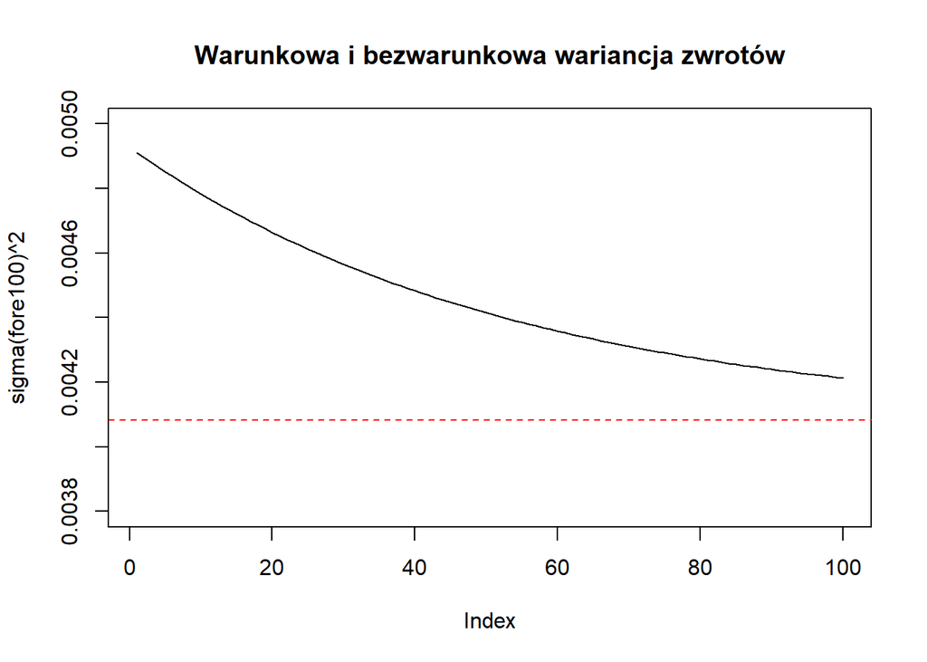

```r
# wykres
plot(sigma(fore100)^2, type = "l",  ylim = c(0.0038, 0.0050))
abline(h = var_uncond, col = "red", lty = 2)
title(main = "Warunkowa i bezwarunkowa wariancja zwrotów")
```

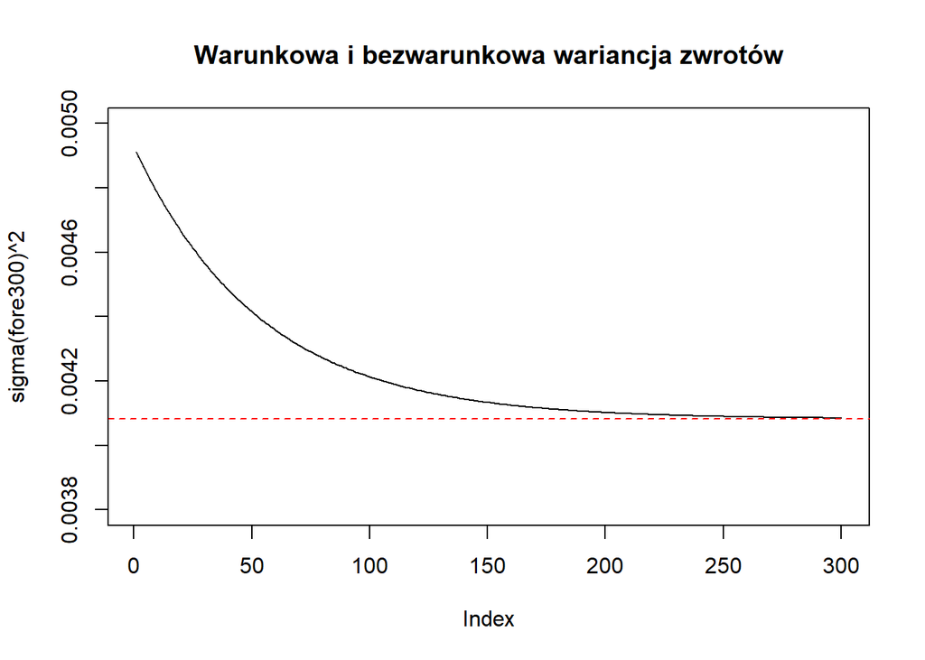

```r
# analogicznie dla 300 okresóW
fore300 <- ugarchforecast(ins.garch11mu0, n.ahead = 300)
plot(sigma(fore300)^2, type = "l",  ylim = c(0.0038, 0.0050))
abline(h = var_uncond, col = "red", lty = 2)
title(main = "Warunkowa i bezwarunkowa wariancja zwrotów")
```

Zgodnie z założeniami modelu prognozy warunkowej wariancji zbiegają w długim okresie do poziomu wariancji bezwarunkowej. Model prognozuje wygasanie wariancji.

### **VAULE-AT-RISK**

```r
ins <- ins[ins$Date > as.Date("2017-09-18"), ] # ucięcie jednej brakującej obserwacji

# standaryzacja zwrotow i pierwszy kwantyl empiryczny in sample
ins$total_r_std <- (ins$total_r - mean(ins$total_r, na.rm=T)) /
  sd(ins$total_r, na.rm = T)

total_r_std_q01 <- quantile(ins$total_r_std, 0.01, na.rm = T)
total_r_std_q01

#### VaR w okresie in sample
ins.garch11mu0@fit$sigma
```

[output not shown]

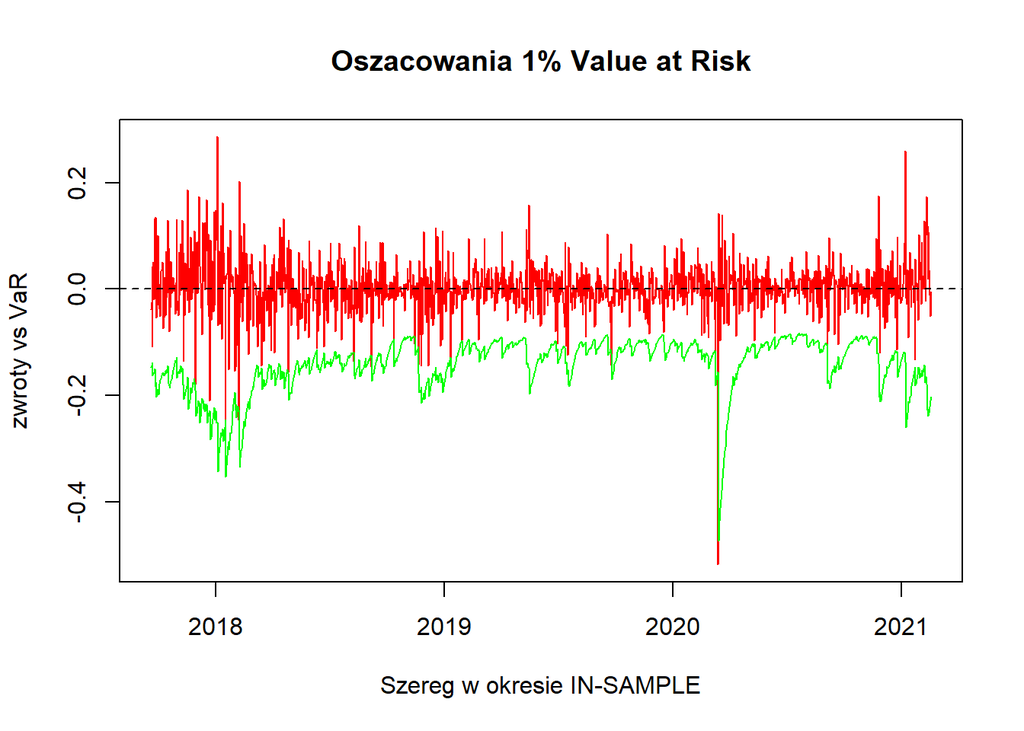

```r
# obliczanie wartości narażonej na ryzyko
ins$VaR <- total_r_std_q01 * ins.garch11mu0@fit$sigma

# wyres zwrotóW i VaR
plot(ins$Date, ins$total_r, col = "red", lwd = 1, type = 'l',
     ylab = "zwroty vs VaR", xlab = "Szereg w okresie IN-SAMPLE", main = "Oszacowania 1% Value at Risk")
abline(h = 0, lty = 2)
lines(ins$Date, ins$VaR, type = 'l', col = "green")
```

```r
# w ilu przypadkach straty przekroczyły zakładany poziom VaR?
sum(ins$total_r < ins$VaR) / length(ins$VaR) # 0.009638554
```

```
## [1] 0.009638554
```

Powyższy wykres przedstwawia wartość narażoną na ryzyko w okresie in sample. Przyjęty poziom istotności to 1%. Straty przekraczają zakładany poziom w około 1% przypadków.

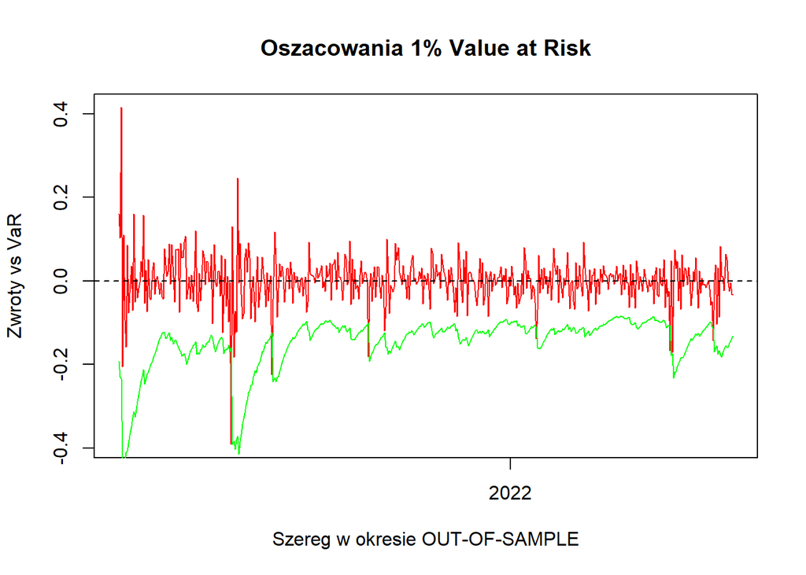

```r
#### VaR w okresie OUT-OF-SAMPLE

# 1-dniowa prognoza warunkowego odchylenia standardowego
#plot(ugarchforecast(ins.garch11mu0, n.ahead = 1))

sigma.forecast <- ugarchforecast(ins.garch11mu0, n.ahead = 1)
sigma.forecast2 <- sigma.forecast@forecast$sigmaFor[1, 1]

# Szacowanie 1-dniowej VaR dla całego okresu OUT-OF-SAMPLE
data$obs = 1:length(data$total_r)
start  <- data$obs[data$Date == as.Date("2021-02-18")]
finish <- data$obs[data$Date == as.Date("2022-06-30")]
data2 <-data[start:finish, ]
VaR <- rep(NA, times = finish - start + 1)

for (k in start:finish) {
  tmp.data <- data[data$obs <= (k - 1), ]
  tmp.data$rstd <- (tmp.data$total_r - mean(tmp.data$total_r, na.rm = T)) /
    sd(tmp.data$total_r, na.rm = T)
  q01 <- quantile(tmp.data$rstd, 0.01, na.rm = T)
  spec <- ugarchspec(variance.model = list(model = "sGARCH",
                                           garchOrder = c(1, 1)),
                     mean.model = list(armaOrder = c(0, 0),
                                       include.mean = F),
                     distribution.model = "norm")
  tmp.garch11mu0 <- ugarchfit(spec = spec, data = na.omit(tmp.data$total_r))
  sigma.forecast  <- ugarchforecast(tmp.garch11mu0, n.ahead = 1)
  sigma.forecast2 <- sigma.forecast@forecast$sigmaFor[1, 1]
  VaR[k - start + 1] <- q01 * sigma.forecast2
}

data2$VaR <- VaR

# wyres zwrotóW i VaR w okresie OUT-OF-SAMPLE

plot(data2$Date, data2$total_r, col = "red", lwd = 1, type = 'l',
     ylab = "Zwroty vs VaR", xlab = "Szereg w okresie OUT-OF-SAMPLE", main = "Oszacowania 1% Value at Risk")
abline(h = 0, lty = 2)
lines(data2$Date, data2$VaR, type = 'l', col = "green")
```

```r
# w ilu przypadkach straty przekroczyły zakładany poziom VaR

sum(data2$total_r < data2$VaR) / length(data2$VaR) # 0.01204819
```

```
## [1] 0.01204819
```

W okresie out of sample straty przekroczyły zakładany poziom w około 1,2% przypadków. Jest to zadowalający poziom, szczególnie gdy weźmiemy pod uwagę niestabilną rzeczywistość pandemiczną na rynkach finansowych. Największą słabością modelu jest rozkład reszt, który zauważalnie odbiega od normalnego.

## **GARCH-t**

Poniżej przeprowadzona została analogiczna analiza dla modelu GARCH-t. Testy w poprzednim przykladzie pokazaly, że rozklad reszt nie jest normalny, więc być może reszty lepiej opisze rozklad t-studenta

```r
# GARCH(1,1) #


spec <- ugarchspec(
  variance.model = list(model = "sGARCH",
                        garchOrder = c(1, 1)),
  mean.model = list(armaOrder = c(0, 0),
                    include.mean = T),
  distribution.model = "std")

ins.garch11 <- ugarchfit(spec = spec,
                         data = na.omit(ins$total_r))


# MA(1)-GARCH(1,1) #

spec <- ugarchspec(
  variance.model = list(model = "sGARCH",
                        garchOrder = c(1, 1)),
  mean.model = list(armaOrder = c(0, 1),
                    include.mean = T),
  distribution.model = "std")

ins.garch11ma1 <- ugarchfit(spec = spec,
                         data = na.omit(ins$total_r))

# AR(1)-GARCH(1,1) #

spec <- ugarchspec(
  variance.model = list(model = "sGARCH",
                        garchOrder = c(1, 1)),
  mean.model = list(armaOrder = c(1, 0),
                    include.mean = T),
  distribution.model = "std")

ins.garch11ar1 <- ugarchfit(spec = spec,
                         data = na.omit(ins$total_r))

# ARMA(1,1)-GARCH(1,1) #

spec <- ugarchspec(
  variance.model = list(model = "sGARCH",
                        garchOrder = c(1, 1)),
  mean.model = list(armaOrder = c(1, 1),
                    include.mean = T),
  distribution.model = "std")

ins.garch11arma11 <- ugarchfit(spec = spec,
                         data = na.omit(ins$total_r))

# GARCH(1,1) mu = 0 #

spec <- ugarchspec(
  variance.model = list(model = "sGARCH",
                        garchOrder = c(1, 1)),
  mean.model = list(armaOrder = c(0, 0),
                    include.mean = F),
  distribution.model = "std")

ins.garch11mu0 <- ugarchfit(spec = spec,
                         data = na.omit(ins$total_r))

# ARMA(1,1)-GARCH(1,1) mu = 0 #

spec <- ugarchspec(
  variance.model = list(model = "sGARCH",
                        garchOrder = c(1, 1)),
  mean.model = list(armaOrder = c(1, 1),
                    include.mean = F),
  distribution.model = "std")

ins.garch11arma11mu0 <- ugarchfit(spec = spec,
                         data = na.omit(ins$total_r))

# MA(1)-GARCH(1,1) mu = 0  #

spec <- ugarchspec(
  variance.model = list(model = "sGARCH",
                        garchOrder = c(1, 1)),
  mean.model = list(armaOrder = c(0, 1),
                    include.mean = F),
  distribution.model = "std")

ins.garch11ma1mu0 <- ugarchfit(spec = spec,
                         data = na.omit(ins$total_r))

# AR(1)-GARCH(1,1) mu = 0  #

spec <- ugarchspec(
  variance.model = list(model = "sGARCH",
                        garchOrder = c(1, 1)),
  mean.model = list(armaOrder = c(1, 0),
                    include.mean = F),
  distribution.model = "std")

ins.garch11ar1mu0 <- ugarchfit(spec = spec,
                         data = na.omit(ins$total_r))
```

##### PORÓWNANIE WSZYSTKICH ZBUDOWANYCH MODELI

```r
infocriteria(ins.garch11)
```

```
##
## Akaike       -3.325320
## Bayes        -3.304730
## Shibata      -3.325352
## Hannan-Quinn -3.317578
```

```r
infocriteria(ins.garch11ma1)
```

```
##
## Akaike       -3.336070
## Bayes        -3.311362
## Shibata      -3.336116
## Hannan-Quinn -3.326780
```

```r
infocriteria(ins.garch11ar1)
```

```
##
## Akaike       -3.337172
## Bayes        -3.312464
## Shibata      -3.337218
## Hannan-Quinn -3.327882
```

```r
infocriteria(ins.garch11arma11)
```

```
##
## Akaike       -3.336764
## Bayes        -3.307938
## Shibata      -3.336827
## Hannan-Quinn -3.325926
```

```r
infocriteria(ins.garch11mu0)
```

```
##
## Akaike       -3.323155
## Bayes        -3.306684
## Shibata      -3.323176
## Hannan-Quinn -3.316962
```

```r
infocriteria(ins.garch11ma1mu0)
```

```
##
## Akaike       -3.332858
## Bayes        -3.312268
## Shibata      -3.332890
## Hannan-Quinn -3.325116
```

```r
infocriteria(ins.garch11ar1mu0)
```

```
##
## Akaike       -3.333929
## Bayes        -3.313339
## Shibata      -3.333961
## Hannan-Quinn -3.326187
```

```r
infocriteria(ins.garch11arma11mu0)
```

```
##
## Akaike       -3.333651
## Bayes        -3.308943
## Shibata      -3.333697
## Hannan-Quinn -3.324361
```

Model AR(1) GARCH(1,1)-t ma najniższe wartości dla 3 z 4 kryteriów informacyjnych. Na tej podstawie został wybrany do dalszej analizy.

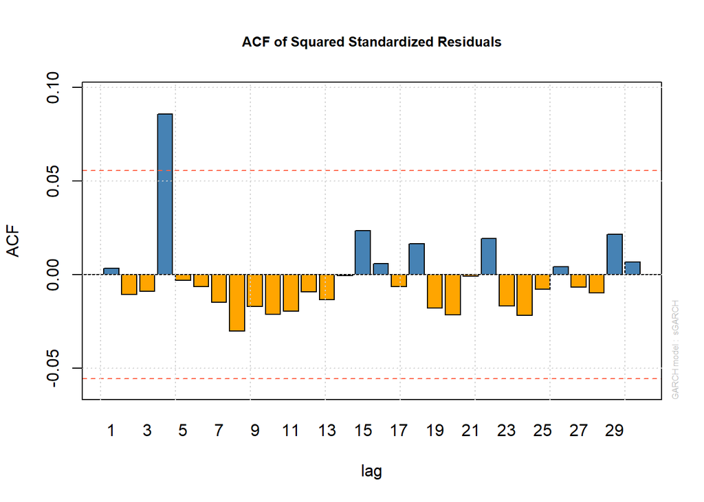

```r
plot(ins.garch11ar1, which = 11)
```

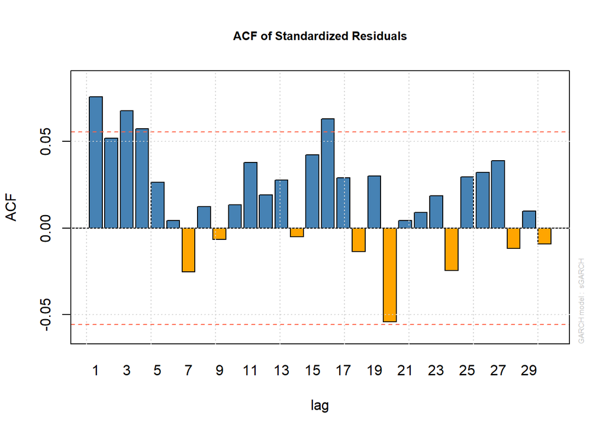

```r
plot(ins.garch11ar1, which = 10)
```

Wykresy wyglądają nieco gorzej niż w poprzednim modelu. Wykres ACF dla kwadratów reszt ponownie pokazuje tylko jedną istotną wartość. Pozostałe są znacząco nieistotne, więc można przyjąć to za satysfakcjonujący rezultat. Autokorelacja jest istotna dla 4 opóźnień, więc model nie radzi sobie z jej odpowiednim zaadresowaniem.

```r
ins.garch11ar1
```

```
##
## *---------------------------------*
## *          GARCH Model Fit        *
## *---------------------------------*
##
## Conditional Variance Dynamics
## -----------------------------------
## GARCH Model  : sGARCH(1,1)
## Mean Model   : ARFIMA(1,0,0)
## Distribution : std
##
## Optimal Parameters
## ------------------------------------
##         Estimate  Std. Error  t value Pr(>|t|)
## mu      0.002347    0.000952   2.4652 0.013695
## ar1    -0.107806    0.025837  -4.1725 0.000030
## omega   0.000049    0.000023   2.1305 0.033131
## alpha1  0.069208    0.019857   3.4853 0.000492
## beta1   0.922605    0.019586  47.1054 0.000000
## shape   3.507952    0.378101   9.2778 0.000000
##
## Robust Standard Errors:
##         Estimate  Std. Error  t value Pr(>|t|)
## mu      0.002347    0.001023   2.2941 0.021783
## ar1    -0.107806    0.023664  -4.5556 0.000005
## omega   0.000049    0.000026   1.9163 0.055325
## alpha1  0.069208    0.019705   3.5122 0.000444
## beta1   0.922605    0.020945  44.0498 0.000000
## shape   3.507952    0.355115   9.8784 0.000000
##
## LogLikelihood : 2083.39
##
## Information Criteria
## ------------------------------------
##
## Akaike       -3.3372
## Bayes        -3.3125
## Shibata      -3.3372
## Hannan-Quinn -3.3279
##
```

[output cut: 43 more lines]

```
## Negative Sign Bias  0.4645 0.64234
## Positive Sign Bias  1.1986 0.23091
## Joint Effect        3.6732 0.29898
##
##
## Adjusted Pearson Goodness-of-Fit Test:
## ------------------------------------
##   group statistic p-value(g-1)
## 1    20     21.94      0.28726
## 2    30     36.08      0.17112
## 3    40     46.98      0.17797
## 4    50     65.08      0.06176
##
##
## Elapsed time : 0.281621
```

Wsztystkie zmienne w modelu są statystycznie istotne (poziom p-value 0.055327 dla zmiennej omega uważamy za dopuszczalny). Test Ljung-Box’a nie daje podstaw do odrzucenia H0 o braku autokolelacji kwadratów reszt dla każdego z opóźnień. Test na występowanie efektów ARCH wypada nieco gorzej niż w poprzednim modelu. Dla 5 opóźnień p-value wynosi 0,027, więc na poziomie 5% należałoby odrzucić H0 o braku efektu w resztach. Ponownie wraca problem autokorelacji. Tym razem formalny test nakazuje odrzucić H0 o jej braku. Jednakże jak opisano wyżej, problem ten nie musi drastycznie zaburzać wnioskowania z modelu.

##### STATYSTYKI RESZT MODELU

```r
empstats <- basicStats(ins.garch11ar1@fit$residuals)
knitr::kable(as.matrix(empstats), digits = 2)
```

|  | X..ins.garch11ar1.fit.residuals |
| --- | --- |
| nobs | 1245.00 |
| NAs | 0.00 |
| Minimum | -0.52 |
| Maximum | 0.29 |
| 1. Quartile | -0.02 |
| 3. Quartile | 0.03 |
| Mean | 0.00 |
| Median | 0.00 |
| Sum | 0.15 |
| SE Mean | 0.00 |
| LCL Mean | 0.00 |
| UCL Mean | 0.00 |
| Variance | 0.00 |
| Stdev | 0.05 |
| Skewness | -0.78 |
| Kurtosis | 10.31 |

##### WYKRES RESZT

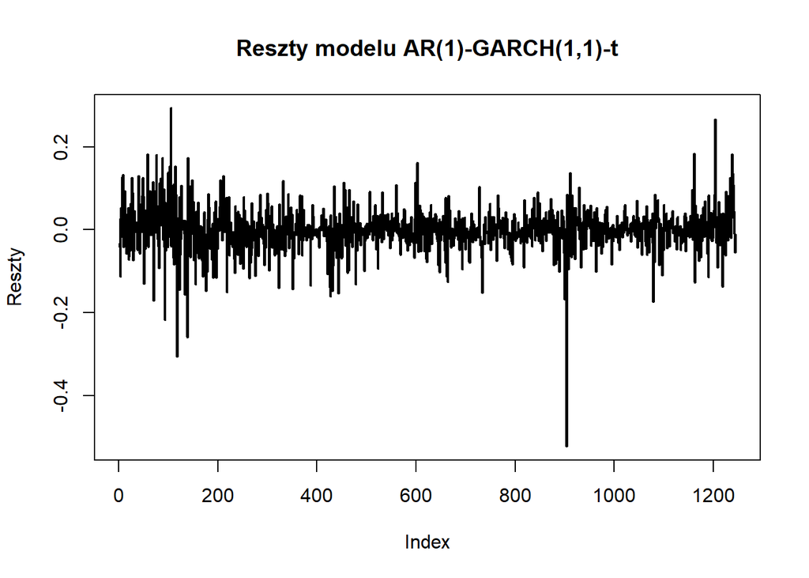

```r
plot(ins.garch11ar1@fit$residuals, type ="l", lwd = 2, main = "Reszty modelu AR(1)-GARCH(1,1)-t", ylab = "Reszty")
```

Wykres pokazuje, że reszty są procesem stacjonarnym. Model prawdopodobnie nie zaabsorbował odpowiednio zjawiska grupowania wariancji.

### **PROGNOZY W. WARIANCJI**

```r
# oceny parametrów
ins.garch11ar1@fit$coef
```

```
##            mu           ar1         omega        alpha1         beta1
##  2.346522e-03 -1.078060e-01  4.893405e-05  6.920822e-02  9.226051e-01
##         shape
##  3.507952e+00
```

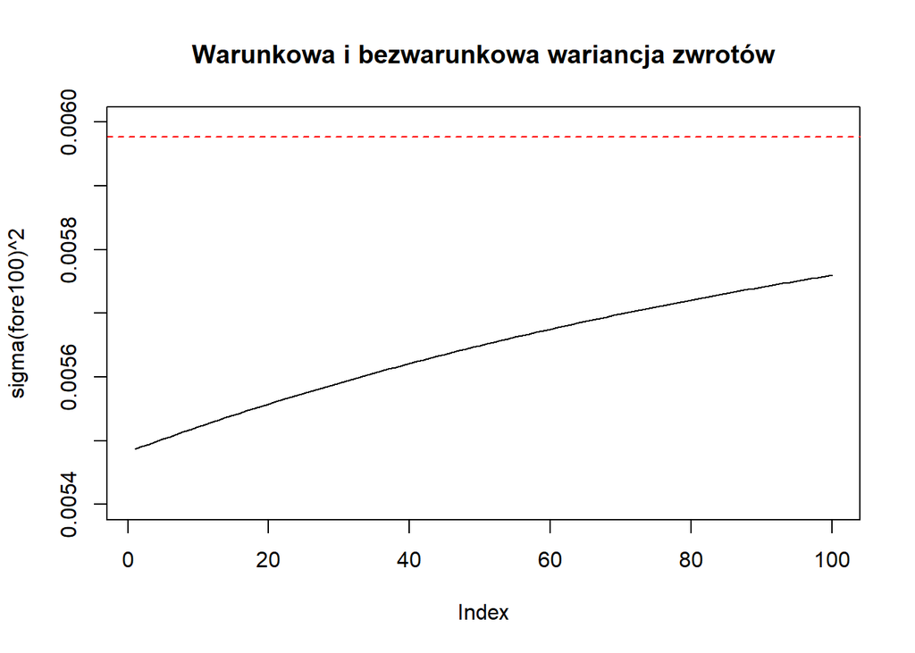

```r
# bezwarunkowa wariancja
var_uncond <- ins.garch11ar1@fit$coef[3] / (1 - ins.garch11ar1@fit$coef[4]
                                            - ins.garch11ar1@fit$coef[5])
names(var_uncond) <- "unconditional variance"
#var_uncond

# prognozy warunkowej wariancji na 100 okresóW
fore100 <- ugarchforecast(ins.garch11ar1, n.ahead = 100)
#sigma(fore100)

# wykres
plot(sigma(fore100)^2, type = "l",  ylim = c(0.0054, 0.006))
abline(h = var_uncond, col = "red", lty = 2)
title(main = "Warunkowa i bezwarunkowa wariancja zwrotów")
```

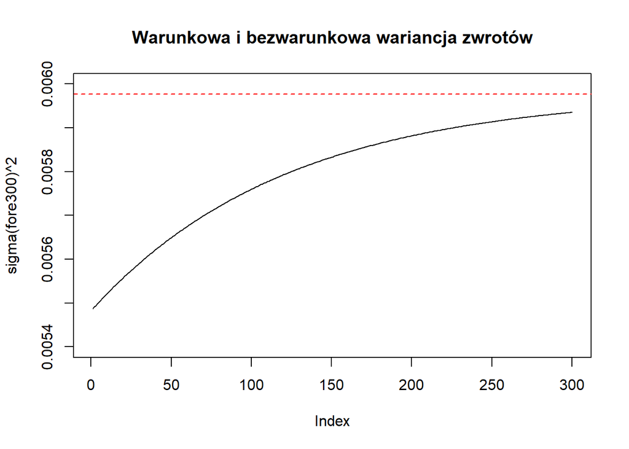

```r
# analogicznie dla 300 okresóW
fore300 <- ugarchforecast(ins.garch11ar1, n.ahead = 300)
plot(sigma(fore300)^2, type = "l",  ylim = c(0.0054, 0.006))
abline(h = var_uncond, col = "red", lty = 2)
title(main = "Warunkowa i bezwarunkowa wariancja zwrotów")
```

Zgodnie z oczekiwaniami prognozy warunkowej wariancji zbiegają w długim okresie do poziomu wariancji bezwarunkowej. Co ciekawe wnioski są lustrzanym odbiciem rezultatów poprzedniego modelu. W tamtym wypadku zaobserowaliśmy wygaszanie wariancji.

### **VAULE-AT-RISK**

```r
ins <- ins[ins$Date > as.Date("2017-09-18"), ] # ucięcie jednej brakującej obserwacji

# standaryzacja zwrotow i pierwszy kwantyl empiryczny in sample
ins$total_r_std <- (ins$total_r - mean(ins$total_r, na.rm=T)) /
  sd(ins$total_r, na.rm = T)

total_r_std_q01 <- quantile(ins$total_r_std, 0.01, na.rm = T)
total_r_std_q01
```

```
##        1%
## -2.735723
```

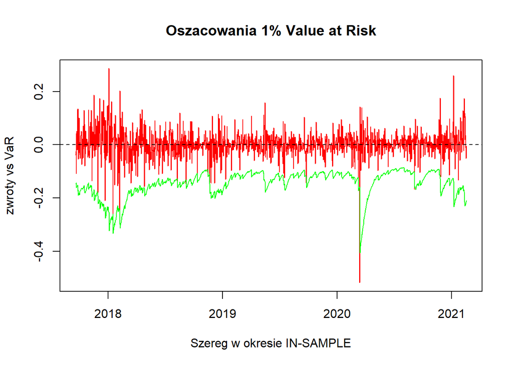

```r
#### VaR w okresie in sample
#ins.garch11ar1@fit$sigma


# obliczanie wartości narażonej na ryzyko
ins$VaR <- total_r_std_q01 * ins.garch11ar1@fit$sigma

# wyres zwrotóW i VaR
plot(ins$Date, ins$total_r, col = "red", lwd = 1, type = 'l',
     ylab = "zwroty vs VaR", xlab = "Szereg w okresie IN-SAMPLE", main = "Oszacowania 1% Value at Risk")
abline(h = 0, lty = 2)
lines(ins$Date, ins$VaR, type = 'l', col = "green")
```

```r
# w ilu przypadkach straty przekroczyły zakładany poziom VaR?
sum(ins$total_r < ins$VaR) / length(ins$VaR) # 0.008835341
```

```
## [1] 0.008835341
```

W okresie in sample straty przekraczają zakładany poziom VaR w około 0,8% przypadków.

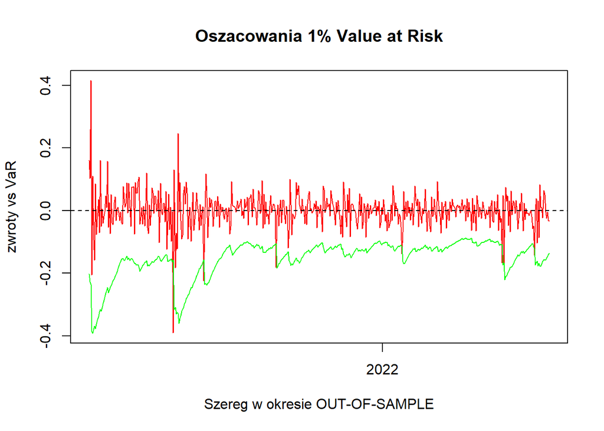

```r
#### VaR w okresie OUT-OF-SAMPLE

# 1-dniowa prognoza warunkowego odchylenia standardowego
#plot(ugarchforecast(ins.garch11ar1, n.ahead = 1))

sigma.forecast <- ugarchforecast(ins.garch11ar1, n.ahead = 1)
sigma.forecast2 <- sigma.forecast@forecast$sigmaFor[1, 1]

# Szacowanie 1-dniowej VaR dla całego okresu OUT-OF-SAMPLE
data$obs = 1:length(data$total_r)
start  <- data$obs[data$Date == as.Date("2021-02-18")]
finish <- data$obs[data$Date == as.Date("2022-06-30")]
data2 <-data[start:finish, ]
VaR <- rep(NA, times = finish - start + 1)

for (k in start:finish) {
  tmp.data <- data[data$obs <= (k - 1), ]
  tmp.data$rstd <- (tmp.data$total_r - mean(tmp.data$total_r, na.rm = T)) /
    sd(tmp.data$total_r, na.rm = T)
  q01 <- quantile(tmp.data$rstd, 0.01, na.rm = T)
  spec <- ugarchspec(variance.model = list(model = "sGARCH",
                                           garchOrder = c(1, 1)),
                     mean.model = list(armaOrder = c(1, 0),
                                       include.mean = T),
                     distribution.model = "std")
  tmp.garch11ar1 <- ugarchfit(spec = spec, data = na.omit(tmp.data$total_r))
  sigma.forecast  <- ugarchforecast(tmp.garch11ar1, n.ahead = 1)
  sigma.forecast2 <- sigma.forecast@forecast$sigmaFor[1, 1]
  VaR[k - start + 1] <- q01 * sigma.forecast2
}

data2$VaR <- VaR

# wyres zwrotóW i VaR w okresie OUT-OF-SAMPLE

plot(data2$Date, data2$total_r, col = "red", lwd = 1, type = 'l',
     ylab = "zwroty vs VaR", xlab = "Szereg w okresie OUT-OF-SAMPLE", main = "Oszacowania 1% Value at Risk")
abline(h = 0, lty = 2)
lines(data2$Date, data2$VaR, type = 'l', col = "green")
```

```r
# w ilu przypadkach straty przekroczyły zakładany poziom VaR

sum(data2$total_r < data2$VaR) / length(data2$VaR) # 0.01405622
```

```
## [1] 0.01405622
```

W okresie out of sample straty przekraczają zakładany poziom VaR w około 1,4% przypadków. Są to wyniki bardzo zbliżone do poprzedniego modelu.